# Lab 5: Factors in Visualizations

This lab comes from the plotting “best practices” that I’ve learned over the years. The main inspiration is [Will Chase’s 2020 RStudio Conference Presentation](https://www.youtube.com/watch?v=h5cTacaWE6I) – Glamour of Graphics.

[figure not shown]

# 1 Revisiting Rodents

We will be working with the `survey.csv` data from Lab 2: Exploring Rodents with ggplot2

- Where did you save this data file?
- You might want to remind yourself what is contained in this data set.

## 1.1 Revisiting Side-by-Side Boxplots

Let’s start with the side-by-side boxplots you created in Lab 2 to visualize the distribution of weight within each species (not species ID!).

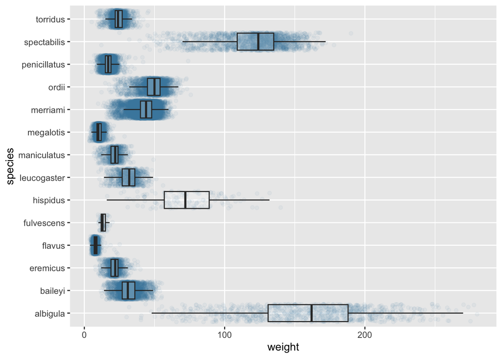

```r
surveys |>
  ggplot(mapping = aes(x = weight,
                       y = species)) +
  geom_jitter(color = "steelblue",
              alpha = 0.05) +
  geom_boxplot(alpha = 0.2,
               outlier.shape = NA)
```

As you should expect with a character variable, the boxplots go in **alphabetical order**. This looks rather jumbled, so let’s put our factor skills to work!

**1. Reorder the boxplots so the weights go in descending order.**

**Caution**

You are required to use functions from `forcats` to complete this task.

**2. Now that you’ve reordered, let’s fix our axis labels and title. Make sure your labels contain important information (e.g., units). Let’s take Will Chase’s advice and incorporate the y-axis label into the plot title–make your title fun!**

## 1.2 Time-Series Plot

**Warning**

This is a new section, meaning you will create a **new** plot. In other words, this is not a continuation of the boxplot from above.

This week, we are focusing on learning skills related to dates, but we have yet to make a very common type of plot – the time-series plot. We’ll use this plot to motivate a second type of factor reordering!

**3. Create a visualization of how weights vary for each genus over the duration of the study.**

**Tip**

What variables do you need and what are their variable types? What aesthetic would it make sense to map each variable to? Sketch it out first!

**Avoid using faceting here.**

Alright, there are a lot of measurements over time! Let’s use our `dplyr` skills to summarize each year and plot the summaries.

**4. Calculate and plot the mean weight for each year (for each genus).**

This should look much less busy! However, you should notice that the legend still goes in alphabetical order.

**5. Reorder the legend line colors so the weights go in descending order.**

**Caution**

You are required to use functions from `forcats` to complete this task.

**6. Now that you’ve reordered the lines, look at your labels and title. Let’s give the legend, axes, and plot new titles *and* move the y-axis label to the top of the plot.**

## 1.3 Caputures over the Week

For our final exploration, we will consider the number of rodents captured throughout the week – transitioning to visualizations of categorical variables.

**Warning**

Your plots **should not** make people tilt their heads to read it! Be mindful in choosing which variable goes on which axis and if / how you use axis labels.

**7. Create a visualization of the number of rodents captured each day of the week.**

As you might have expected, the ordering of the days of the week is not what we would like.

**8. Change the order of the day of the week to go Monday through Sunday.**

**Note**

You can choose to keep the days named as they are (e.g., Mon, Sun), or you can choose to rename the days to their full names (e.g., Monday, Sunday).

It should be very clear that there are more rodents captured on the weekend than during the week. But, let’s explore if this is still the case if we use a “Weekday” / “Weekend” classification system instead.

**10. Collapse Monday through Friday into a `"Weekday"` level, and collapse Saturday and Sunday into a `"Weekend"` level. Plot the number of rodents captured between the two groups.**

# 2 Challenge 5 – Getting Creative

Find one of your favorite pieces of graphical artwork. You are welcome to choose whatever medium you want (e.g., paintings, digital art, photography, graffiti), the only requirement is the art you pick needs to have **colors**.

[figure not shown]

Once you’ve found your artwork, upload the image to this color picker app: https://imagecolorpicker.com/

The app should give you a palette with 10 colors selected from the image, but you can also manually click on any location in the plot and get the color.

Now that you have a set of colors, use the [`scale_color_manual()`](https://ggplot2.tidyverse.org/reference/scale_manual.html) function to incorporate the colors from this artwork into the plots you made for Lab 5.

**Include the image of the artwork you chose here:**

**You will need to save the image in your repository!**

**Include a description of *why* you chose this artwork:**